# Machine Learning Notes

### *Clustering*

Most of the examples so far have been “supervised learning”, meaning that we told the computer the right answers for the training data and asked it to tune algorithms to drive better fits to these right answers. Clustering on the other hand is an example of “unsupervised learning”, meaning that we just give the computer the raw data but not the answer. Clustering is commonly run when the goal is to identify groups that behave like each other. Examples could be customer segmentation, social network analysis, or astronomy.

K-means is one of the most common forms of clustering. The algorithm works as follows:

- Assume you have m observations each consisting of a length-n vector of features
- Choose K centroids and specify an initial position for each centroid
- REPEAT START: Assign each point to the nearest centroid
- REPEAT CONTINUE: Move the centroid position to the average of its members
- REPEAT END: Upon hitting convergence
- REPEAT CAUTION: If a cluster has zero data points, either delete it (down to K-1 clsuters total) or make a new random centroid

The k-means optimization function is to minimize the “distortion”, defined as the average euclidean distance between every point and its centroid. It can be shown mathematically that the steps described above continually decrease the distortion, though it is possible to get trapped by local minima.

A common approach is to run the k-means clustering multiple times, keeping only the final clusters with the “best” distortion cost. Specifically, it is common to just pick K training data points and use these as the starting centroids. There is no perfect method of picking the number of clusters, K. While it is possible to plot distortion cost vs. K, there is not always an obvious point of diminishing returns. As such, domain expertise becomes very valuable at this stage.

An example is again drawn from the Ng Coursera Octave files:

```r
library(R.matlab, quietly=TRUE)

matPath <- "../../../OctaveDirectory/Week08/"  # Using relative path
wgtData <- "ex7data1.mat"

listMATData <- readMat(paste0(matPath, wgtData))
str(listMATData)  # Check that as expected - list with one item, $X
```

```
## List of 1
##  $ X: num [1:50, 1:2] 3.38 4.53 2.66 2.77 2.85 ...
##  - attr(*, "header")=List of 3
##   ..$ description: chr "MATLAB 5.0 MAT-file, Platform: PCWIN64, Created on: Mon Nov 14 22:41:44 2011                                                "
##   ..$ version    : chr "5"
##   ..$ endian     : chr "little"
```

```r
kMeansX <- listMATData$X  # First item in the list should be 50x2
str(kMeansX)  # Check that 50x2 and matricized
```

```
##  num [1:50, 1:2] 3.38 4.53 2.66 2.77 2.85 ...
```

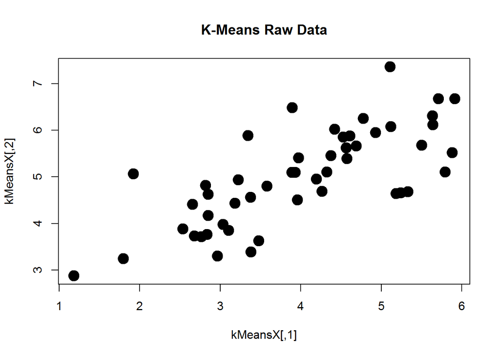

```r
plot(kMeansX, pch=19, cex=2, main="K-Means Raw Data")
```

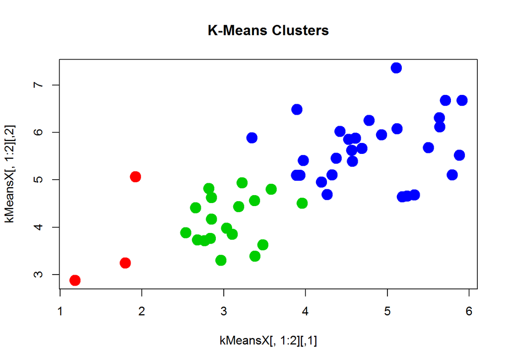

```r
K = 3  # Default to 3 clusters

# Make a place to store each distance and the final cluster
kMeansX <- cbind(kMeansX, matrix(data=NA, nrow=nrow(kMeansX), ncol=K+1))
kCost <- NA

foo <- function(x, fixedPoint) { sum((x - fixedPoint)^2) }

set.seed(2016053119)

# Try 1 run to find the best clusters
kCentroids <- kMeansX[sample(nrow(kMeansX), K), 1:2]

# Iterate 10 times each
for (intCtr2 in 1:10) {
    for (kCtr in 1:K) {
        kMeansX[ , 2+kCtr] <- apply(kMeansX[, 1:2], 1, FUN=foo, fixedPoint=kCentroids[kCtr, ])
    }
    kMeansX[ , ncol(kMeansX)] <- apply(kMeansX[, 3:(ncol(kMeansX)-1)], 1, FUN=which.min )
    kCentroids[ , 1] <- tapply(kMeansX[, 1], kMeansX[, ncol(kMeansX)], FUN=mean)
    kCentroids[ , 2] <- tapply(kMeansX[, 2], kMeansX[, ncol(kMeansX)], FUN=mean)
}

plot(kMeansX[ , 1:2], pch=19, cex=2, main="K-Means Clusters", col=1 + kMeansX[ , ncol(kMeansX)])
```

The single-run algorithm grouped a few outliers (red) as well as splitting low (green) vs. high (blue). Of interest is how well this compares with the pre-programmed R routine:

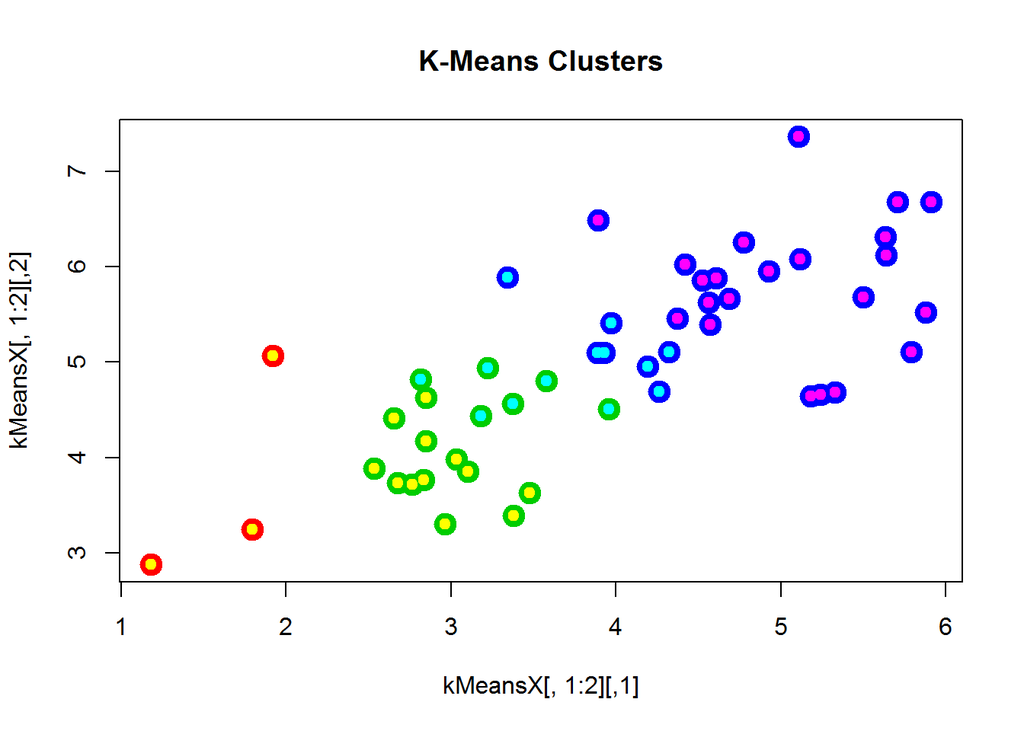

```r
rKMeans <- kmeans(kMeansX[ , 1:2], centers=K)
plot(kMeansX[ , 1:2], pch=19, cex=2, main="K-Means Clusters", col=1 + kMeansX[ , ncol(kMeansX)])
points(kMeansX[ , 1:2], pch=19, cex=1, col=4 + rKMeans$cluster)
```

And, it is obvious that the clusters do not always converge to the same global minima.

### *Dimension Reduction Background*

Dimension reduction is the idea that it may not take all n features to richly describe the data, particularly when there are strong correlations (and thus redundancies) among some combinations of features. There are typically two main objectives behind dimension reduction:

1. Data compression for faster processing time - if 100 features describe the data nearly as well as 1,000 features, saving ~90% of the disk space, memory, CPU time, etc., may be warranted
2. Visulaization - since humans are typically limited to 2D (perhaps 3D with nice graphics) visuals, finding 2-3 dimensions that strongly describe the data can be attractive. For example, with OECD data there could be a “size” dimension and a “per capita” dimension

As an example, the k-means algorithm can be used for image compression, again using data from the Ng Coursera modules:

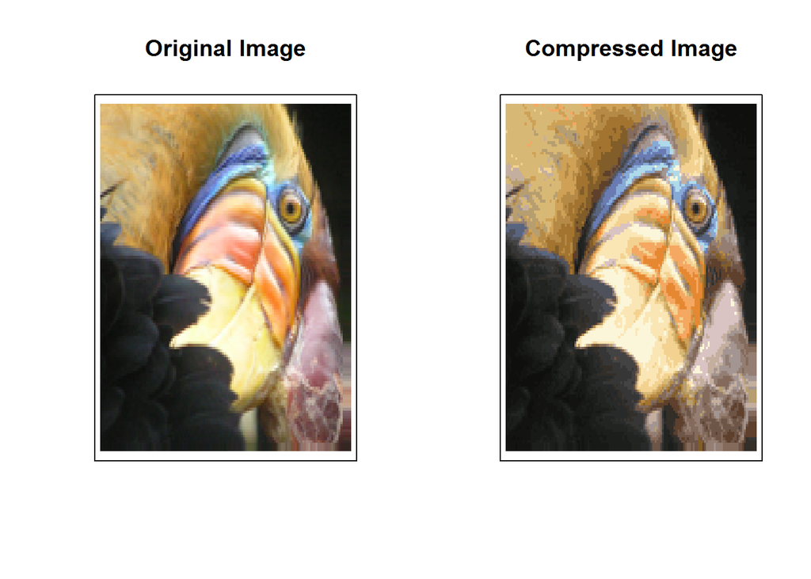

```r
library(png)

matPath <- "../../../OctaveDirectory/Week08/"  # Using relative path
birdData <- "bird_small.png"

birdArray <- readPNG(paste0(matPath, birdData))
birdSize <- dim(birdArray)[1]

posX <- numeric(birdSize^2)
posY <- numeric(birdSize^2)

for (intCtr in 1:(birdSize^2)) {
    posX[intCtr] <- (intCtr-1) %/% birdSize
    posY[intCtr] <- (intCtr-1) %% birdSize
}

par(mfrow=c(1,2))

# Original bird plot
plot(posX, -posY, col=rgb(birdArray[,,1], birdArray[,,2], birdArray[,,3]), pch=15,
     xaxt="n", yaxt="n", main="Original Image", xlab="", ylab=""
     )

# Run k-means on the colors to pick out just the "best" 32
birdKMeans <- kmeans(matrix(data=aperm(birdArray), ncol=3, byrow=TRUE), centers=32)
plot(posY, -posX, col=rgb(birdKMeans$centers[birdKMeans$cluster, 1],
                          birdKMeans$centers[birdKMeans$cluster, 2],
                          birdKMeans$centers[birdKMeans$cluster, 3]
                          ),
     pch=15, xaxt="n", yaxt="n", main="Compressed Image", xlab="", ylab=""
     )
```

```r
par(mfrow=c(1,1))
```

### *Principal Component Analysis (PCA)*

PCA is a common technique for data compression. The problem objective is to minimize the sum-squared distances (project errors) to the project line. Feature scaling/normalization to mean=0, sd=1 is nearly always applied prior to PCA. By convention, the projection vectors are denoted as “u”.

While the actual algorithm is fairly complex, it is well-implemented as one of the results of running SVD (singular vector decomposition). In R, this is implemented as base::svd(), returning a list with:

- $u, the left singular vectors
- $d, the values of the diagonal matrix
- $v, the right singular vectors

A few properties include:

- The sum of the first n $d divided by the total sum($d) describes the total variance captured by the first n principal components
- X = U % * % diag(D) % * % t(V)
- D = t(U) % * % X % * % V

For example, continuing with the bird RGB data:

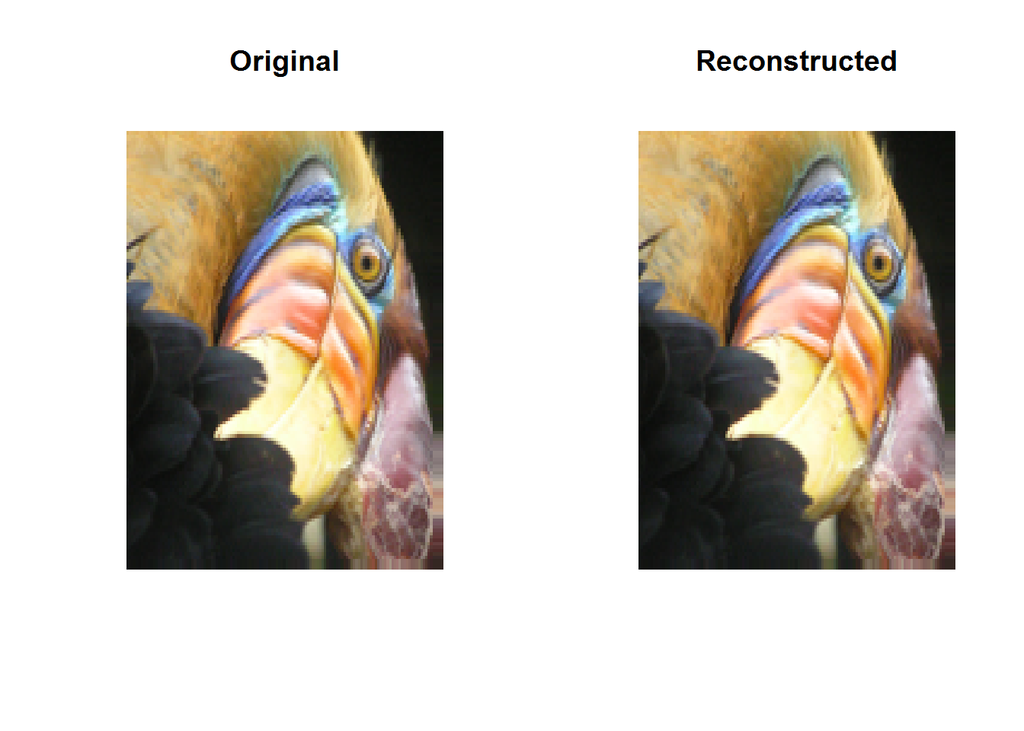

```r
par(mfrow=c(1,2))


birdColors <- matrix(data=aperm(birdArray), ncol=3, byrow=TRUE)
plot((0:16383) %% 128, -((0:16383) %/% 128), col=rgb(birdColors),
     pch=15, axes=FALSE, xlab="", ylab="", main="Original"
     )

# Run SVD
svdColors <- svd(birdColors)

# Verify decomposition
reconColors <- svdColors$u %*% diag(svdColors$d) %*% t(svdColors$v)
reconColors[which(reconColors > 1)] <- 1
plot((0:16383) %% 128, -((0:16383) %/% 128), col=rgb(reconColors),
     pch=15, axes=FALSE, xlab="", ylab="", main="Reconstructed"
     )
```

```r
# Verify diagnonal
reconD <- t(svdColors$u) %*% birdColors %*% svdColors$v
diag(reconD) - svdColors$d
```

```
## [1] 6.252776e-13 3.943512e-13 2.220446e-14
```

```r
par(mfrow=c(1,1))
```

And, suppose that you then wanted to just take the first singular value and do a mapping against that:

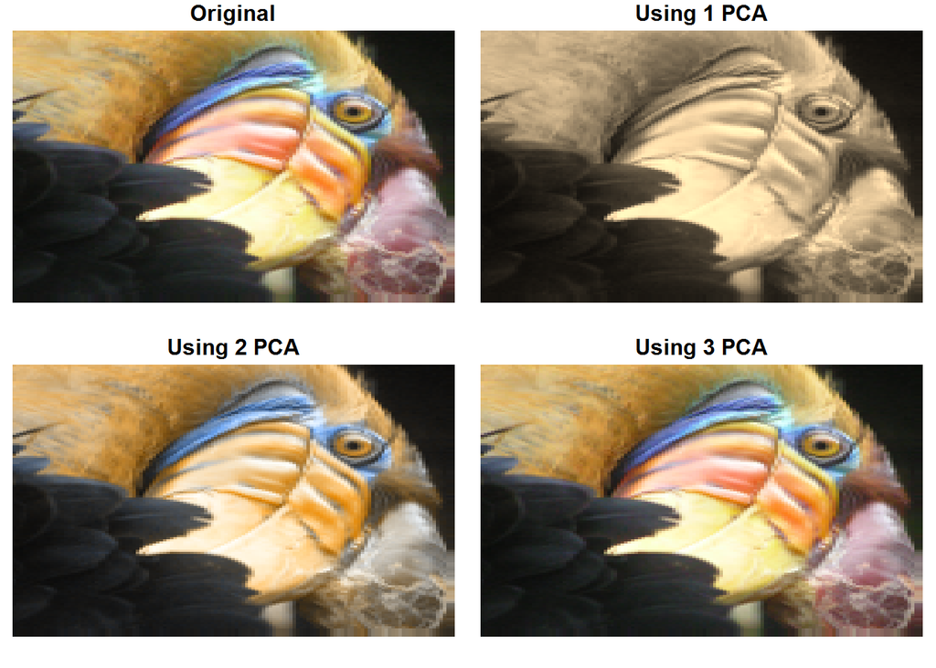

```r
# Take just the first column
maxSVD <- 3

par(mfrow=c(2, 2))
defMar <- par()$mar
par(mar=c(1.1, 0, 1.1, 0))


plot((0:16383) %% 128, -((0:16383) %/% 128), col=rgb(birdColors),
     pch=15, axes=FALSE, xlab="", ylab="", main="Original"
     )

# Run the compressions
picSVD <- vector("list", maxSVD)
for (intCtr in 1:maxSVD) {
    picSVD[[intCtr]] <- svdColors$u[ ,1:intCtr] %*%
                        diag(svdColors$d[1:intCtr], nrow=intCtr) %*%
                        t(svdColors$v[, 1:intCtr])

    picSVD[[intCtr]][which(picSVD[[intCtr]] > 1)] <- 1
    plot((0:16383) %% 128, -((0:16383) %/% 128),
         col=rgb(matrix(data=aperm(picSVD[[intCtr]]), ncol=3, byrow=TRUE)),
         pch=15, axes=FALSE, xlab="", ylab="", main=paste0("Using ", intCtr, " PCA")
         )

}
```

```r
par(mar=defMar)
par(mfrow=c(1, 1))
```

In this case, the first PCA is primarily capturing the grayscale of the image, which is very accurate as to features. The second PCA pulls in a good chunk of the colors, while the third PCA brings back the full image. This could be especially advantageous if the image were large and the colors were not just described by a simple RGB.

Often, PCA are captured only until 90%, 95%, or 99% of the total variation in the raw data is retained. Algorithms can then be run on the smaller subspace of features post-PCA. A few other notes about PCA:

- PCA should only be run on the training data, with resulting SVD used to transform test data as needed
- It is common to get a 5x or 10x reduction in data sizes (and thus processing times) using PCA
- However, PCA is not a panacea and should be considered after some exploratory analysis. If the project can be feasibly completed (run times, memory, etc.) without PCA, then that is frequently for the better

### *Density Estimation and Anomalies*

Anomaly detection is a common unsupervised machine learning problem, for example in fraud detection or monitoring a group of servers. The main thrust is to identify anomalies that merit follow-up by a human, as opposed to supervised learning where the main goal is often accuracy. That is not to say that accuracy does not matter; crying wolf is still a big problem (e.g., declining too many valid credit card charges). Rather it is to say that the algorithm is just looking for things that differ from normal.

The Gaussian distribution is commonly used. Suppose you have n features about m historical observations, and categorize these as x(1), x(2), . . . , x(m). Suppose also that each of the features can be assumed to be normal with mean mu and standard deviation sigma. For each of the histoircal features:

- mu = (1/m) * sum( feature )
- sigma = (1/m) * sum( (feature - mu)^2 ), noting that machine learning usually uses 1/m rather than 1/(m-1)
- p(x; mu, sigma) = ( 1 / [ sqrt(2 * pi) * sigma ] ) * exp[ -(x - mu)^2 / (2 * sigma^2) ]

That is to say that the normal pdf (dnorm) provides some guidance as to how likely this specific occurence is. Note that in this case we are not using the typical “area under the curve” from statistics. Instead, we look at the actual probability from dnorm().

Suppose we have an unlabeled training set with independent features (the next section covers the case of dependent features). Then, we can define p(x) = p(x1; mu1, sigma1) * p(x2; mu2, sigma2) * . . . * p(xn; mun, sigman), commonly format as p(x) = PI ( p(xj; muj, sigmaj) ). The algorithm is then fairly simple:

- Choose a set of features of interest
- Find mu and sigma based on a relevant reference dataset (ideally, iid from all “good” or “normal” conditions, though that is not strictly required)
- Given any new example, calculate p(x) = PI ( p(xj; muj, sigmaj) ), where PI means “product over”
- Declare an anomaly any time p(x) < epsilon, with epsilon driving the ratio between false positives (declaring normal things anomalous) and false negatives (failing to find true anomalies)

It is very common in the anomaly detection world that the overwhelming majority of observations will not be anomalous. This means that a good CV/Test process with a proper metric (such as F1 score) can be valuable in picking the best epsilon for the task at hand. A common example might be:

- 10,000 normal (good) engines have been produced along with 20 bad engines, and we have historical feature data and a true classification for each
- TRAIN: Common to train on 6,000 good engines
- CV: Common to run CV on 2,000 good engines and 10 bad engines
- TEST: Common to run Test on 2,000 good engines and 10 bad engines

The TRAIN data is used to calculate mu, sigma, while the CV data is then used to calculate an epsilon with a desirable Precision, Recall, F1, etc.. The TEST data serves as guidance on expected out-of-sample results.

Anomaly detection is preferred to supervised learning since it is hard to predict in advance which feature will be the outlier, and extremely difficult to train a model on 20 bad cases which may each be very different than all other bad cases. Anomaly detection benefits by taking a simpler angle - it is not trying to flag that a new engine is “bad”; instead, it is flagging that the new engine looks different than the historical good engines. There is no pre-conceived notion of how that needs to occur - it could be normal on all features but 20-sigma off on 1, or it could be 2-sigma off on all features or etc.

Choosing the right features can be an art, and an important one. A few guiding principles include:

- The more Gaussian the features the better - see if a transformation can help improve a feature
- Ideal to see relatively large p(x) for most good cases, with much smaller p(x) for the anomalies. If not, work with a domain expert to see if there may be a missing feature
- Further, see if ratios of features might make sense, again in conjunction with a domain expert. For example, high CPU with high memory usage might be expected as might low CPU with low memory usage. But, high CPU with low memory usage might signal an infinite loop or other condition that should be checked by a systems engineer; if so, CPU/memory could become an interesting feature

Example data is again taken from the Ng Coursera Machine Learning course:

```r
library(R.matlab, quietly=TRUE)

matPath <- "../../../OctaveDirectory/Week09/"  # Using relative path
wgtData <- "ex8data1.mat"

listMATData <- readMat(paste0(matPath, wgtData))
str(listMATData)  # Check that as expected - list with three items, $X, $Xval, $yval
```

```
## List of 3
##  $ X   : num [1:307, 1:2] 13 13.4 14.2 14.9 13.6 ...
##  $ Xval: num [1:307, 1:2] 15.8 13.6 14.9 13.6 13.5 ...
##  $ yval: num [1:307, 1] 0 0 0 0 0 0 0 0 0 1 ...
##  - attr(*, "header")=List of 3
##   ..$ description: chr "MATLAB 5.0 MAT-file, Platform: GLNXA64, Created on: Thu Dec  1 15:37:10 2011                                                "
##   ..$ version    : chr "5"
##   ..$ endian     : chr "little"
```

```r
trainX <- listMATData$X
cvX <- listMATData$Xval
cvY <- listMATData$yval

str(trainX)  # Validate that 307x2 matrix
```

```
##  num [1:307, 1:2] 13 13.4 14.2 14.9 13.6 ...
```

```r
str(cvX)  # Validate that 307x2 matrix
```

```
##  num [1:307, 1:2] 15.8 13.6 14.9 13.6 13.5 ...
```

```r
str(cvY)  # Validate that 307x1 matrix
```

```
##  num [1:307, 1] 0 0 0 0 0 0 0 0 0 1 ...
```

First, we calculate mu and sigma for each feature (column) of trainX, and use that to calculate the associated probabilities for each sample in the training data. Then, we use the CV data to determine a good choice for epsilon:

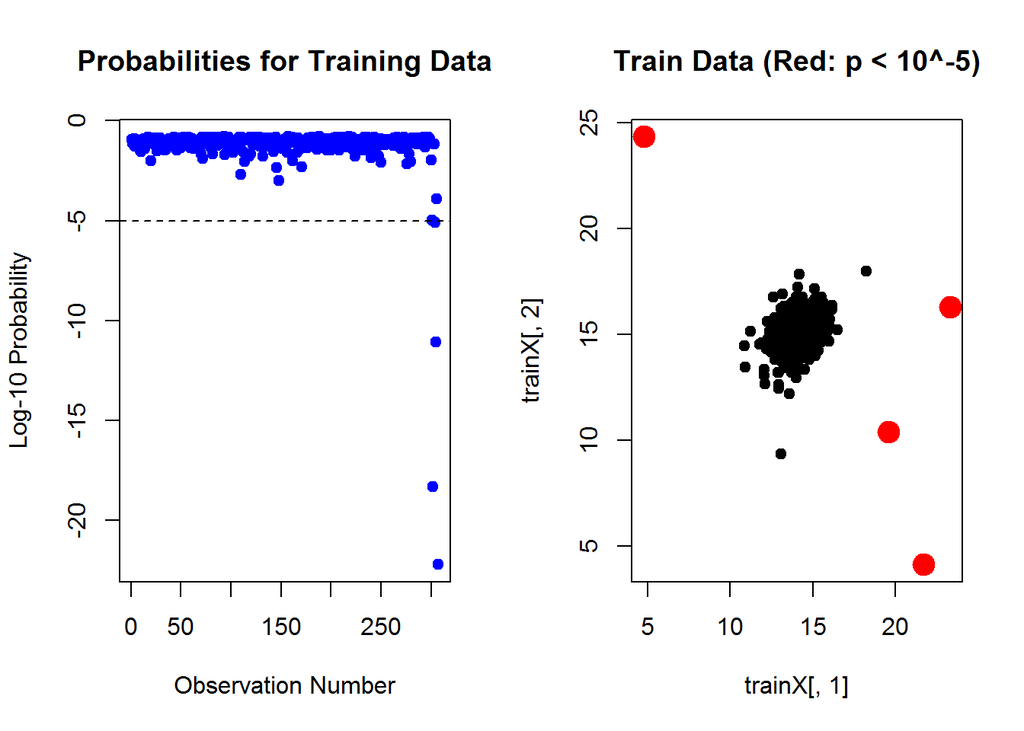

```r
muTrain <- apply(trainX, 2, FUN=mean)
sigmaTrain <- apply(trainX, 2, FUN=sd)  # Will return 1/(m-1) rather than 1/m

pTrain <- apply(dnorm(trainX/sigmaTrain, mean=muTrain/sigmaTrain, sd=1), 1, FUN=prod)

par(mfrow=c(1,2))


plot(log10(pTrain), pch=19, col="blue", main="Probabilities for Training Data",
     ylab="Log-10 Probability", xlab="Observation Number"
     )
abline(h=-5, lty=2, lwd=1)

plot(trainX[,1], trainX[,2], col=1 + (pTrain < 10^-5), pch=19, cex=1 + (pTrain < 10^-5),
     main="Train Data (Red: p < 10^-5)")
```

```r
par(mfrow=c(1,1))


testF1 <- 0
useEps <- 0

probCV <- apply(dnorm(cvX/sigmaTrain, mean=muTrain/sigmaTrain, sd=1), 1, FUN=prod)  # Use train mu/sigma

for (testEps in probCV[order(probCV)][2:length(probCV)]) {
    # Precision is TP / (TP + FP) or TP / (declared positive)
    precCV <- sum( ( probCV < testEps ) & ( cvY == 1 ) ) / sum(probCV < testEps)

    # Recall is TP / (TP + FN) or TP / (actually positive)
    recCV <- sum( ( probCV < testEps ) & ( cvY == 1 ) ) / sum( cvY == 1 )

    # F1 = 2 * P * R / (P + R)
    f1CV <- 2 * precCV * recCV / (precCV + recCV)

    if (f1CV > testF1) {
        useEps <- testEps
        testF1 <- f1CV
    }
}

print(paste0("Best fit found at log10(epsilon): ", round(log10(useEps),3),
             " driving CV F1=", round(testF1,3))
      )
```

```
## [1] "Best fit found at log10(epsilon): -3.047 driving CV F1=0.875"
```

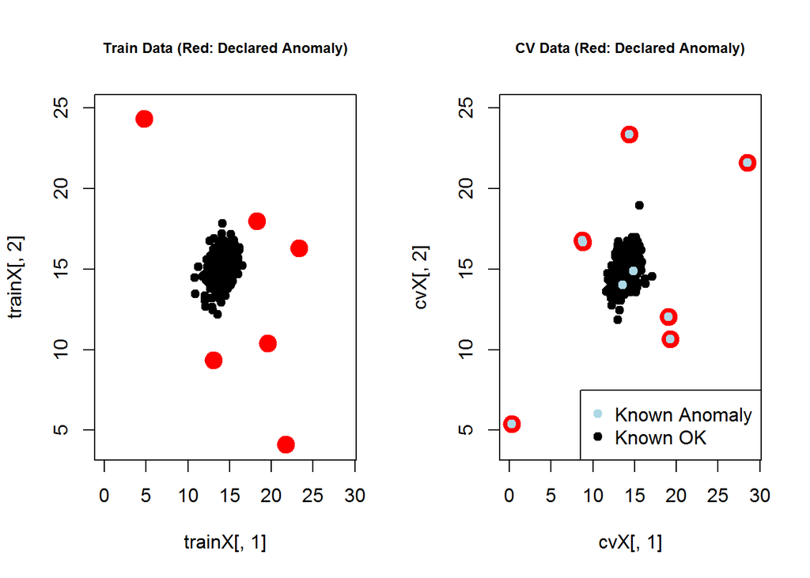

```r
par(mfrow=c(1,2))


xLim <- c( floor(min(trainX[,1], cvX[,1])), ceiling(max(trainX[,1], cvX[,1])) )
yLim <- c( floor(min(trainX[,2], cvX[,2])), ceiling(max(trainX[,2], cvX[,2])) )

plot(trainX[,1], trainX[,2], col=1 + (pTrain < useEps), pch=19, cex=1 + (pTrain < useEps),
     main="Train Data (Red: Declared Anomaly)", cex.main=0.75, xlim=xLim, ylim=yLim
     )

plot(cvX[,1], cvX[,2], col=1 + (probCV < useEps), pch=19, cex=1 + (probCV < useEps),
     main="CV Data (Red: Declared Anomaly)", cex.main=0.75, xlim=xLim, ylim=yLim
     )
points(cvX[cvY == 1, 1], cvX[cvY == 1, 2], pch=19, col="lightblue")
legend("bottomright", legend=c("Known Anomaly", "Known OK"), pch=19, col=c("lightblue", "black"))
```

```r
par(mfrow=c(1,1))
```

In this example, the algorithm flags 6 points in the training data as anomalies. These would be good to explore with a domain expert in the interest of potentially further tuning the model.

In this example, the algorithm correctly flags 6 points in the CV data as anomalies, avoids classifying any normal data as anomalies, and fails to identify 2 actual anomalies. Since these 2 anomalies are close to tge center of the cloud, there may be a missing feature. This would be ideal to explore further with a domain expert.

### *Multivariate Gaussian Distribution*

The multivariate Gaussian is an extension to anomaly detection where the algorithm can automatically detect correlations among the features (no longer need to assume feature independence). The key change for the multivariate Gaussian approach is to model p(x) all in a single go:

- Define mu to be an nx1 vector of the column means
- Define Sigma to be an nxn covariance matrix for the columns
- p(x ; mu, Sigma) = ( 1 / [ (2 * pi)^(n/2) * sqrt(length(Sigma)) ] ) * exp[ -0.5 * t((x - mu) % * % solve(Sigma) % * % (x - mu) ]
- length(Sigma) is defined as being the determinant of Sigma
- Off-diagnonals in the Sigma matrix will tend to force correlations (clouds) among the data entries

```r
library(R.matlab, quietly=TRUE)

matPath <- "../../../OctaveDirectory/Week09/"  # Using relative path
wgtData <- "ex8data2.mat"

listMATData <- readMat(paste0(matPath, wgtData))
str(listMATData)  # Check that as expected - list with three items, $X, $Xval, $yval
```

```
## List of 3
##  $ X   : num [1:1000, 1:11] 6.65 -5.63 9.72 -4.64 -12.84 ...
##  $ Xval: num [1:100, 1:11] 18.27 -3.19 -5.26 12.95 3.76 ...
##  $ yval: num [1:100, 1] 1 0 0 1 0 0 0 0 0 0 ...
##  - attr(*, "header")=List of 3
##   ..$ description: chr "MATLAB 5.0 MAT-file, Platform: GLNXA64, Created on: Thu Dec  1 23:12:48 2011                                                "
##   ..$ version    : chr "5"
##   ..$ endian     : chr "little"
```

```r
trainX <- listMATData$X
cvX <- listMATData$Xval
cvY <- listMATData$yval

str(trainX)  # Validate that 1000x11 matrix
```

```
##  num [1:1000, 1:11] 6.65 -5.63 9.72 -4.64 -12.84 ...
```

```r
str(cvX)  # Validate that 100x11 matrix
```

```
##  num [1:100, 1:11] 18.27 -3.19 -5.26 12.95 3.76 ...
```

```r
str(cvY)  # Validate that 100x1 matrix
```

```
##  num [1:100, 1] 1 0 0 1 0 0 0 0 0 0 ...
```

First, we calculate mu and Sigma based on the training data, as well as the associated inverse/determinant for Sigma. We then apply these to get probabilities for the training and CV data:

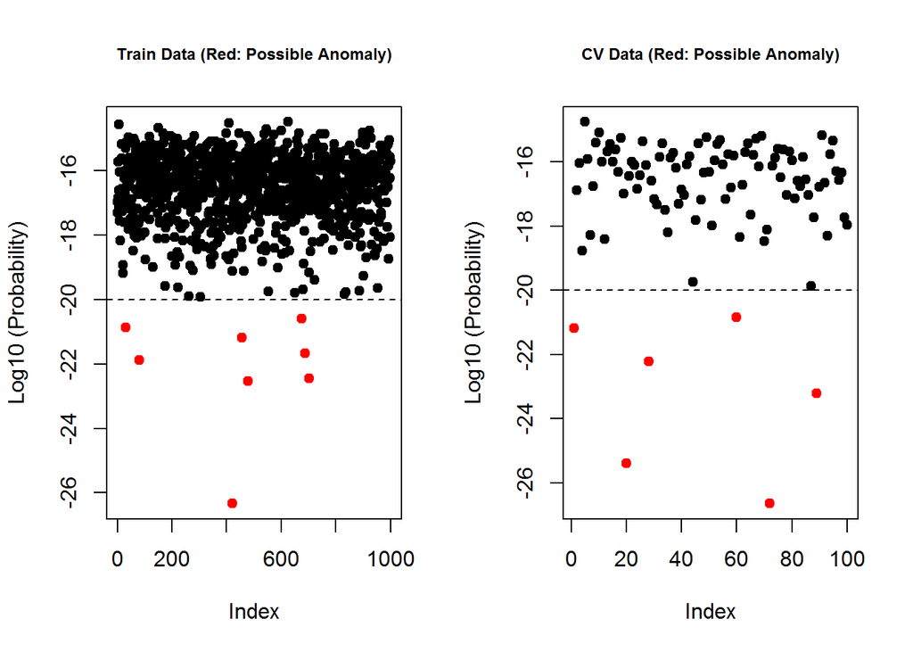

```r
muTrain <- apply(trainX, 2, FUN=mean)  ## Should be 1x11 since trainX is mx11
bigSigma <- cov(trainX)  ## Should be 11x11 since trainX is mx11
invSigma <- solve(bigSigma)
detSigma <- det(bigSigma)

multSigma <- 1 / ( (2 * pi)^(0.5 * ncol(trainX)) * sqrt(detSigma) )

foo <- function(x, mu, invSigma) {
    exp( -0.5 * ( matrix(data=(x - mu), ncol=length(x)) %*% invSigma %*%
                  matrix(data=(x - mu), nrow=length(x))
                 )
        )
}

pTrain <- multSigma * apply(trainX, 1, FUN=foo, mu=muTrain, invSigma=invSigma)
probCV <- multSigma * apply(cvX, 1, FUN=foo, mu=muTrain, invSigma=invSigma)


par(mfrow=c(1,2))


plot(log10(pTrain), col=1 + (log10(pTrain) < -20), pch=19,
     main="Train Data (Red: Possible Anomaly)", cex.main=0.75, ylab="Log10 (Probability)"
     )
abline(h=-20, lty=2)

plot(log10(probCV), col=1 + (log10(probCV) < -20), pch=19,
     main="CV Data (Red: Possible Anomaly)", cex.main=0.75, ylab="Log10 (Probability)"
     )
abline(h=-20, lty=2)
```

```r
par(mfrow=c(1,1))
```

Then, run the same epsilon-finding process as above:

```r
testF1 <- 0
useEps <- 0

for (testEps in probCV[order(probCV)][2:length(probCV)]) {
    # Precision is TP / (TP + FP) or TP / (declared positive)
    precCV <- sum( ( probCV < testEps ) & ( cvY == 1 ) ) / sum(probCV < testEps)

    # Recall is TP / (TP + FN) or TP / (actually positive)
    recCV <- sum( ( probCV < testEps ) & ( cvY == 1 ) ) / sum( cvY == 1 )

    # F1 = 2 * P * R / (P + R)
    f1CV <- 2 * precCV * recCV / (precCV + recCV)

    if (f1CV > testF1) {
        useEps <- testEps
        testF1 <- f1CV
    }
}

print(paste0("Best fit found at log10(epsilon): ", round(log10(useEps),2)," driving CV F1=", round(testF1,3)))
```

```
## [1] "Best fit found at log10(epsilon): -19.87 driving CV F1=0.75"
```

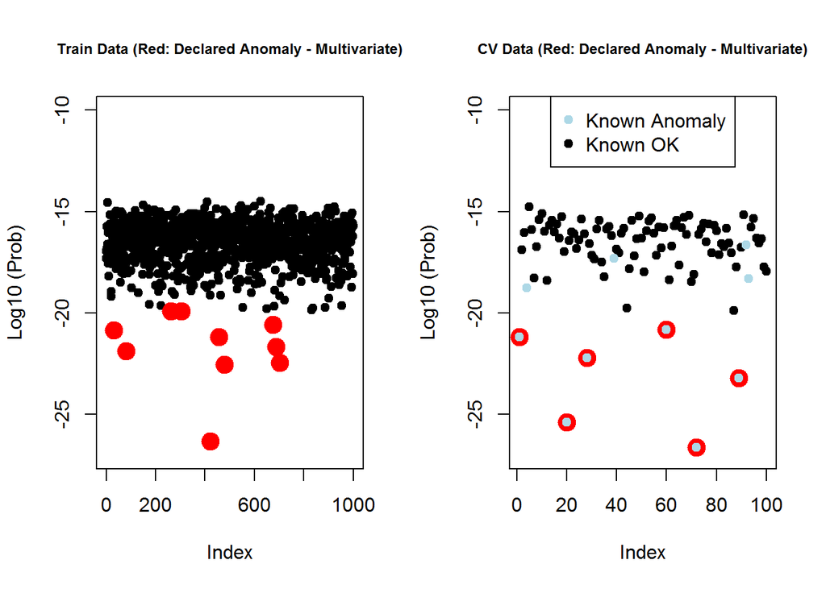

```r
par(mfrow=c(1,2))


yLim <- c( floor(log10(min(probCV, pTrain))), 4 + ceiling(log10(max(probCV, pTrain))) )

plot(log10(pTrain), col=1 + (pTrain < useEps), pch=19, cex=1 + (pTrain < useEps),
     main="Train Data (Red: Declared Anomaly - Multivariate)", cex.main=0.75, ylim=yLim, ylab="Log10 (Prob)"
     )

plot(log10(probCV), col=1 + (probCV < useEps), pch=19, cex=1 + (probCV < useEps),
     main="CV Data (Red: Declared Anomaly - Multivariate)", cex.main=0.75, ylim=yLim, ylab="Log10 (Prob)"
     )
keyX <- which(cvY == 1)
points(keyX, log10(probCV[keyX]), pch=19, col="lightblue")
legend("top", legend=c("Known Anomaly", "Known OK"), pch=19, col=c("lightblue", "black"))
```

```r
par(mfrow=c(1,1))
```

In this case, the algorithm detects 6 of the 10 anomalies in the CV data while never falsely detecting a non-anomaly. Consulting with a domain expert about the 4 missed anomalies could help improve the F1 score.

### *Recommender Systems*

A recommender system relies on input from many users to predict what products other users will like. Good recommendations can be central to the profitability of companies like Amazon and Netflix. As a first example, suppose that your goal is to predict how much a user will like a movie they have not yet watched, assuming that all ratings are on the 0-5 scale.

- Call n(u) the number of users
- Call n(m) the number of movies
- Set r(i, j) = 1 whenever user j has rated movie i (0 or NA otherwise)
- Set y(i, j) as the rating given by user j for movie i, created only in cases where r(i, j)=1
- Suppose you have calculated values for features x0 (bias, always 1), x1, and x2 for each movie; x1 might be degree of romance and x2 might be degree of violence
- Define theta(j) as the prediction vector for user j - how do x0, x1, and x2 combine to make movies good/bad for user j?

The goal is then to learn theta(j) for every user, with a goal of minimizing the prediction costs. Specifically:

- J = (1 / (2 * m(j) ) * sum-over-r(I,j)=1-of [ ( t(theta(j)) * x(i) - y(I, j) )^2 ] + ( lambda / (2 * m(j) ) * sum( theta^2 ), excluding theta0 from the regularization term
- Since m(j) is a constant for the specific user, can multiply by m(j)
- So, J = 0.5 * sum-over-r(I,j)=1-of [ ( t(theta(j)) * x(i) - y(I, j) )^2 ] + ( 0.5 * lambda ) * sum( theta^2 ), excluding theta0 from the regularization term

And then for all users, we would have:

- J(theta(1), theta(2), . . . , theta(n(u)) = { 0.5 * sum-over-j-of [ sum-over-r(I,j)=1-of [ ( t(theta(j)) * x(i) - y(I, j) )^2 ] ] } + 0.5 * lambda * sum-over-j-of [ sum-over-k=1+ of [ theta(k)(j)^2 ] ]
- Gradient Descent: theta(k)(j) = theta(k)(j) - alpha * { sum-over-r(I,j)=1-of [ ( t(theta(j)) * x(i) - y(I, j) ) * x(k)(i) ] + lambda * thata(j)(k) }, noting that lambda should never be applied if k=0

Of course, the challenge is that this algorithm requires creating features for every movie. This could be cumbersome and inaccurate. On the one hand, we could ask each person to declare their own theta vector and then use that to calculate the features for each movie (using cost minimization). But, could we instead ask the algorithm to calculate both the features and theta vector simultaneously?

### *Collaborative Filtering (Background)*

Collaborative filtering is the solution. Each user gives ratings for movies that they have watched, and the algorithm simultaneously solves for features by movie and thetas by user in a manner that minimizes costs. The name comes from the fact that a large group of people are pooling their inputs in a manner that helps make better (lower cost/error) recommendations for everyone.

- J = 0.5 * sum-over-(I,j):r(I,j)=1-of [ ( t(theta(j)) * x(i) - y(I, j) )^2 ] + ( 0.5 * lambda ) * sum( x(k)(i)^2 ) + ( 0.5 * lambda ) * sum( theta^2 )
- There is no longer any need for a bias unit - the algorithm can create a bias unit if it likes
- Each x is an n-dimensional vector, and each theta is an n-dimensional vector; the n features are picked by the model
- Begin by initializing every theta and feature to a small random number (important for breaking symmetry)
- x(k)(i) = x(k)(i) - alpha * { sum-over-j:r(I,j)=1-of [ ( t(theta(j)) * x(i) - y(I, j) ) * theta(k)(j) ] + lambda * x(k)(i) }
- theta(k)(j) = theta(k)(j) - alpha * { sum-over-i:r(I,j)=1-of [ ( t(theta(j)) * x(i) - y(I, j) ) * x(k)(i) ] + lambda * theta(k)(j) }
- After convergence, use t(theta) * x to predict how a user will rate a movie they have not yet seen

While the final features will not have meaning per se, they can be used to group “similar” movies and “similar” users by finding small euclidean distances between movie features and/or user thetas

### *Collaborative Filtering (Example Given Input Matrices)*

An example is again drawn from the Ng Coursera Machine Learning files:

```r
library(R.matlab, quietly=TRUE)

matPath <- "../../../OctaveDirectory/Week09/"  # Using relative path
wgtData <- "ex8_movies.mat"

listMATData <- readMat(paste0(matPath, wgtData))
str(listMATData)  # Check that as expected - list with two items, $Y, $R
```

```
## List of 2
##  $ Y: num [1:1682, 1:943] 5 3 4 3 3 5 4 1 5 3 ...
##  $ R: int [1:1682, 1:943] 1 1 1 1 1 1 1 1 1 1 ...
##  - attr(*, "header")=List of 3
##   ..$ description: chr "MATLAB 5.0 MAT-file, Platform: GLNXA64, Created on: Thu Dec  1 17:19:26 2011                                                "
##   ..$ version    : chr "5"
##   ..$ endian     : chr "little"
```

```r
movieRatings <- listMATData$Y
mtxSparse <- listMATData$R

str(movieRatings)  # Validate that 1682x943 matrix (1682 movies, 943 users)
```

```
##  num [1:1682, 1:943] 5 3 4 3 3 5 4 1 5 3 ...
```

```r
str(mtxSparse)  # Validate that 1682x943 matrix
```

```
##  int [1:1682, 1:943] 1 1 1 1 1 1 1 1 1 1 ...
```

Next an algorithm is created to calculate the cost given the relevant thetas and features:

```r
cofiCost <- function(vecMatrix, mtxY, mtxR, nUser, nMovie, nFeature, lambda) {

    # Roll vecMatrix back to feature matrix and theta matrix
    keyCut <- nMovie * nFeature
    vecX <- vecMatrix[1:keyCut]
    vecTheta <- vecMatrix[(keyCut+1):length(vecMatrix)]
    useX <- matrix(data=vecX, nrow=nMovie, ncol=nFeature, byrow=FALSE)
    useTheta <- matrix(data=vecTheta, nrow=nUser, ncol=nFeature, byrow=FALSE)

    # Calculate cost
    movJ <- 0.5 * sum( ( (useX %*% t(useTheta) - mtxY)^2)[mtxR==1] )
    movJ <- movJ + 0.5 * lambda * ( sum(useX^2) + sum(useTheta^2) )

    return(movJ)
}
```

Then, the sample theta and features from Ng Coursera Machine learning are additionally read-in:

```r
library(R.matlab, quietly=TRUE)

matPath <- "../../../OctaveDirectory/Week09/"  # Using relative path
wgtData <- "ex8_movieParams.mat"

listMATData <- readMat(paste0(matPath, wgtData))
# Check that as expected - list with five items: $X, $Theta, $num.users, $num.movies, $num.features
str(listMATData)
```

```
## List of 5
##  $ X           : num [1:1682, 1:10] 1.049 0.781 0.642 0.454 0.938 ...
##  $ Theta       : num [1:943, 1:10] 0.2854 0.505 -0.4319 0.7286 0.0521 ...
##  $ num.users   : num [1, 1] 943
##  $ num.movies  : num [1, 1] 1682
##  $ num.features: num [1, 1] 10
##  - attr(*, "header")=List of 3
##   ..$ description: chr "MATLAB 5.0 MAT-file, Platform: GLNXA64, Created on: Thu Dec  1 17:16:53 2011                                                "
##   ..$ version    : chr "5"
##   ..$ endian     : chr "little"
```

```r
mtxX <- listMATData$X
mtxTheta <- listMATData$Theta

str(mtxX)  # Validate that 1682x10 matrix (1682 movies, 10 features)
```

```
##  num [1:1682, 1:10] 1.049 0.781 0.642 0.454 0.938 ...
```

```r
str(mtxTheta)  # Validate that 943x10 matrix (943 users, 10 features)
```

```
##  num [1:943, 1:10] 0.2854 0.505 -0.4319 0.7286 0.0521 ...
```

The cost function is then tested for 4 users, 5 movies, and 3 features to ensure it brings back ~22.22 given these base inputs.

```r
# Modify them for the test
nUser <- 4
nMovie <- 5
nFeature <- 3

# Validate that ~22.22
cofiCost(vecMatrix = c(as.vector(mtxX[1:nMovie, 1:nFeature]), as.vector(mtxTheta[1:nUser, 1:nFeature])),
         mtxY = movieRatings[1:nMovie, 1:nUser], mtxR = mtxSparse[1:nMovie, 1:nUser], nUser=nUser,
         nMovie=nMovie, nFeature=nFeature, lambda=0
         )
```

```
## [1] 22.2246
```

```r
# Validate that ~31.34
cofiCost(vecMatrix = c(as.vector(mtxX[1:nMovie, 1:nFeature]), as.vector(mtxTheta[1:nUser, 1:nFeature])),
         mtxY = movieRatings[1:nMovie, 1:nUser], mtxR = mtxSparse[1:nMovie, 1:nUser], nUser=nUser,
         nMovie=nMovie, nFeature=nFeature, lambda=1.5
         )
```

```
## [1] 31.34406
```

```r
# Capture these properly for remainder of program
nUser <- nrow(mtxTheta)
nMovie <- nrow(mtxX)
nFeature <- ncol(mtxX)

# Confirm that runs OK for full dataset also
cofiCost(vecMatrix = c(as.vector(mtxX), as.vector(mtxTheta)), mtxY = movieRatings,
         mtxR = mtxSparse, nUser=nUser, nMovie=nMovie, nFeature=nFeature, lambda=0
         )
```

```
## [1] 27918.64
```

```r
# Confirm that runs OK for full dataset also
cofiCost(vecMatrix = c(as.vector(mtxX), as.vector(mtxTheta)), mtxY = movieRatings,
         mtxR = mtxSparse, nUser=nUser, nMovie=nMovie, nFeature=nFeature, lambda=1.5
         )
```

```
## [1] 34821.7
```

So, provided that we have the proper inputs, we can calculate the associated costs. The next step is to find the gradients and optimize the parameters.

### *Collaborative Filtering (Example Solving for Input Matrices)*

The process of simultaneously solving for theta and features is an example of low rank matrix factorization. The rank of an mxn matrix is typically the smaller of m or n, defining the degree of linear independence that exists in the matrix. However, when certain rows and/or columns are linear combinations of each other, the matrix is no longer considered to be “full rank”. Instead, the matrix is considered to be “rank deficient” and to have rank equal to the smaller of # linearly independent columns/rows. Fortunately, gradient descent works fine even in a rank-deficient environment:

```r
cofiGrad <- function(vecMatrix, mtxY, mtxR, nUser, nMovie, nFeature, lambda) {

    # Roll vecMatrix back to feature matrix and theta matrix
    keyCut <- nMovie * nFeature
    vecX <- vecMatrix[1:keyCut]
    vecTheta <- vecMatrix[(keyCut+1):length(vecMatrix)]
    useX <- matrix(data=vecX, nrow=nMovie, ncol=nFeature, byrow=FALSE)
    useTheta <- matrix(data=vecTheta, nrow=nUser, ncol=nFeature, byrow=FALSE)

    # Calculate gradients
    gradX <- ((useX %*% t(useTheta) - mtxY) * mtxR) %*% useTheta + (lambda * useX)
    gradTheta <- t((useX %*% t(useTheta) - mtxY) * mtxR) %*% useX + (lambda * useTheta)

    return(c(as.vector(gradX), as.vector(gradTheta)))

}
```

Then, we can initialize theta and X as small random numbers (break the symmetry), normalize the movie ratings, and call optim to find the solution:

```r
useLambda=10

# Initialize mtxX and mtxTheta
mtxTheta <- matrix(rnorm(length(mtxTheta)), nrow=nrow(mtxTheta))
mtxX <- matrix(rnorm(length(mtxX)), nrow=nrow(mtxX))

# Normalize movie ratings (movieRatings is 1682 x 943, with each of the 1682 rows being a movie)
movSum <- apply(movieRatings, 1, FUN=sum)
movCount <- apply(mtxSparse, 1, FUN=sum)
movAvg <- movSum / movCount

normRatings <- movieRatings - movAvg * mtxSparse

# cofiGrad <- function(vecMatrix, mtxY, mtxR, nUser, nMovie, nFeature, lambda)
# Initialize vecMatrix
vecMatrix = c(as.vector(mtxX), as.vector(mtxTheta))

startTime <- proc.time()
movList <- optim(vecMatrix, cofiCost, cofiGrad, mtxY=normRatings,
                 mtxR=mtxSparse, nUser=nUser, nMovie=nMovie, nFeature=nFeature,
                 lambda=useLambda, control=list(maxit=50), method="BFGS"
                 )
proc.time() - startTime
```

```
##    user  system elapsed
##  783.00    5.29  793.19
```

This runs much slower than the equivalent in Octave. It may be helpful to explore optim() and/or a faster equivalent in more detail.

### *Tuning R Optimization for Speed*

It would be interesting to understand where the speed challenges occur within R. For example, is the timing gap due to the underlying functions, or due to how optim() pieces everything together? We check this with a few code snippets and proc.time():

```r
# Print the outcomes from the above cached BFGS 50-iteration optimization
str(movList)
```

```
## List of 5
##  $ par        : num [1:26250] -2.917 0.525 -0.431 1.091 -0.176 ...
##  $ value      : num 72215
##  $ counts     : Named int [1:2] 243 50
##   ..- attr(*, "names")= chr [1:2] "function" "gradient"
##  $ convergence: int 1
##  $ message    : NULL
```

```r
# Test the cost calculation function (10 iterations)
startTime <- proc.time()
for (intCtr in 1:10) {
    cofiCost(vecMatrix = c(as.vector(mtxX), as.vector(mtxTheta)), mtxY = movieRatings,
             mtxR = mtxSparse, nUser=nUser, nMovie=nMovie, nFeature=nFeature, lambda=10
             )
}
proc.time() - startTime
```

```
##    user  system elapsed
##    0.45    0.17    0.63
```

```r
# Test the gradient calculation function (10 iterations)
startTime <- proc.time()
for (intCtr in 1:10) {
    cofiGrad(vecMatrix = c(as.vector(mtxX), as.vector(mtxTheta)), mtxY = movieRatings,
             mtxR = mtxSparse, nUser=nUser, nMovie=nMovie, nFeature=nFeature, lambda=10
             )
}
proc.time() - startTime
```

```
##    user  system elapsed
##    0.82    0.34    1.16
```

```r
# Re-initialize thetas and re-create starting vecMatrix
mtxTheta <- matrix(rnorm(length(mtxTheta)), nrow=nrow(mtxTheta))
mtxX <- matrix(rnorm(length(mtxX)), nrow=nrow(mtxX))
vecMatrix = c(as.vector(mtxX), as.vector(mtxTheta))

# Run BFGS with 10 iterations for additional benchmarking
startTime <- proc.time()
movListBFGS010 <- optim(par=vecMatrix, fn=cofiCost, gr=cofiGrad, mtxY=normRatings,
                        mtxR=mtxSparse, nUser=nUser, nMovie=nMovie, nFeature=nFeature,
                        lambda=useLambda, control=list(maxit=10), method="BFGS"
                        )
proc.time() - startTime
```

```
##    user  system elapsed
##  137.01    1.20  138.43
```

```r
str(movListBFGS010)
```

```
## List of 5
##  $ par        : num [1:26250] -3.636 0.482 -0.51 1.202 0.171 ...
##  $ value      : num 160469
##  $ counts     : Named int [1:2] 43 10
##   ..- attr(*, "names")= chr [1:2] "function" "gradient"
##  $ convergence: int 1
##  $ message    : NULL
```

The outcomes are intriguing and show that optim() is the primary time-sink:

So, it appears that the optim() function using BFGS is taking 30x-40x longer than calls to the underlying functions would suggest. One potential reason is that BFGS is storing a matrix - see below for some comments from Details under ?optim:

- Method “BFGS” is a quasi-Newton method (also known as a variable metric algorithm), specifically that published simultaneously in 1970 by Broyden, Fletcher, Goldfarb and Shanno. This uses function values and gradients to build up a picture of the surface to be optimized.
- Method “CG” is a conjugate gradients method based on that by Fletcher and Reeves (1964) (but with the option of Polak-Ribiere or Beale-Sorenson updates). Conjugate gradient methods will generally be more fragile than the BFGS method, but as they do not store a matrix they may be successful in much larger optimization problems.

As such, it would be interesting to test the performance using the conjugate gradients method, particularly since that will be a closer match to what is used in the Octave/MATLAB examples:

```r
# Run for the same 10 ierations
# Re-initialize thetas and re-create starting vecMatrix
mtxTheta <- matrix(rnorm(length(mtxTheta)), nrow=nrow(mtxTheta))
mtxX <- matrix(rnorm(length(mtxX)), nrow=nrow(mtxX))
vecMatrix = c(as.vector(mtxX), as.vector(mtxTheta))

startTime <- proc.time()
movListCG010 <- optim(par=vecMatrix, fn=cofiCost, gr=cofiGrad, mtxY=normRatings,
                      mtxR=mtxSparse, nUser=nUser, nMovie=nMovie, nFeature=nFeature,
                      lambda=useLambda, control=list(maxit=10), method="CG"
                      )
proc.time() - startTime
```

```
##    user  system elapsed
##    2.51    0.53    3.05
```

```r
str(movListCG010)
```

```
## List of 5
##  $ par        : num [1:26250] -0.688 -0.334 -0.462 -0.377 -0.334 ...
##  $ value      : num 44660
##  $ counts     : Named int [1:2] 28 11
##   ..- attr(*, "names")= chr [1:2] "function" "gradient"
##  $ convergence: int 1
##  $ message    : NULL
```

The outcomes are highly suggestive that CG is an all-around better method for this specific example:

So, the CG method seems to take only as long to run as the underlying function calls, and converges to a lower cost with fewer iterations.

The same process is then run using CG with additional iterations - once at 50 iterations, and once at 250 iterations. The theta matrix is again re-initialized each time:

```r
# Run for 50 ierations
# Re-initialize thetas and re-create starting vecMatrix
mtxTheta <- matrix(rnorm(length(mtxTheta)), nrow=nrow(mtxTheta))
mtxX <- matrix(rnorm(length(mtxX)), nrow=nrow(mtxX))
vecMatrix = c(as.vector(mtxX), as.vector(mtxTheta))

startTime <- proc.time()
movListCG050 <- optim(par=vecMatrix, fn=cofiCost, gr=cofiGrad, mtxY=normRatings,
                      mtxR=mtxSparse, nUser=nUser, nMovie=nMovie, nFeature=nFeature,
                      lambda=useLambda, control=list(maxit=50), method="CG"
                      )
proc.time() - startTime
```

```
##    user  system elapsed
##   11.28    2.45   13.74
```

```r
str(movListCG050)
```

```
## List of 5
##  $ par        : num [1:26250] -0.00251 0.05568 -0.19073 0.25088 -0.40891 ...
##  $ value      : num 39268
##  $ counts     : Named int [1:2] 121 51
##   ..- attr(*, "names")= chr [1:2] "function" "gradient"
##  $ convergence: int 1
##  $ message    : NULL
```

```r
# Run for 250 ierations
# Re-initialize thetas and re-create starting vecMatrix
mtxTheta <- matrix(rnorm(length(mtxTheta)), nrow=nrow(mtxTheta))
mtxX <- matrix(rnorm(length(mtxX)), nrow=nrow(mtxX))
vecMatrix = c(as.vector(mtxX), as.vector(mtxTheta))

startTime <- proc.time()
movListCG250 <- optim(par=vecMatrix, fn=cofiCost, gr=cofiGrad, mtxY=normRatings,
                      mtxR=mtxSparse, nUser=nUser, nMovie=nMovie, nFeature=nFeature,
                      lambda=useLambda, control=list(maxit=250), method="CG"
                      )
proc.time() - startTime
```

```
##    user  system elapsed
##   50.03   12.98   63.04
```

```r
str(movListCG250)
```

```
## List of 5
##  $ par        : num [1:26250] -0.244 0.1188 0.0956 0.2165 0.5092 ...
##  $ value      : num 38949
##  $ counts     : Named int [1:2] 587 251
##   ..- attr(*, "names")= chr [1:2] "function" "gradient"
##  $ convergence: int 1
##  $ message    : NULL
```

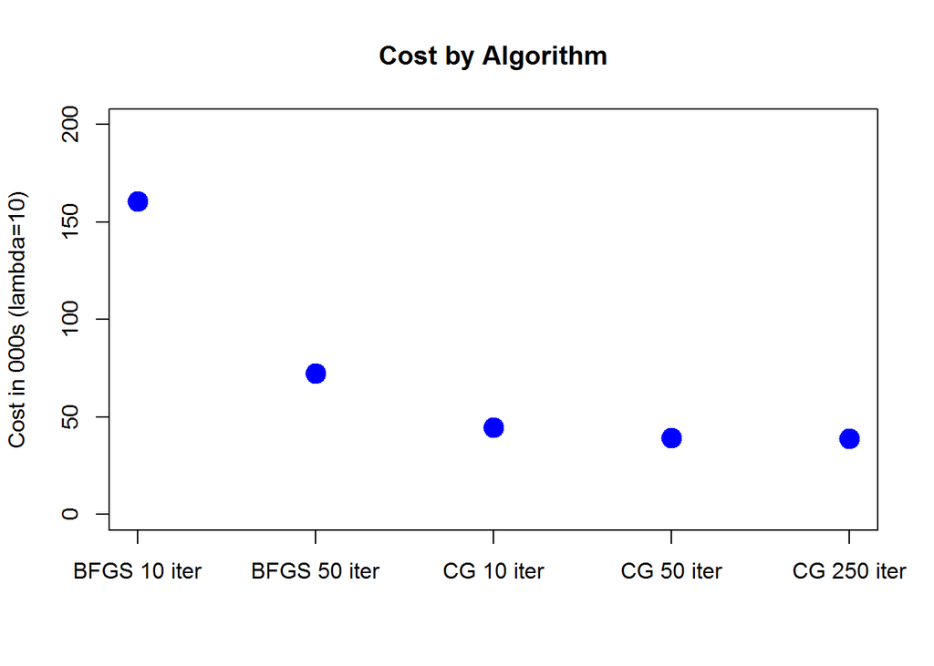

```r
cofiValues <- c(movListBFGS010$value, movList$value, movListCG010$value,
                movListCG050$value, movListCG250$value
                )

plot(cofiValues/1000, xaxt="n", ylab="Cost in 000s (lambda=10)", main="Cost by Algorithm",
     pch=19, col="blue", cex=2, xlab="", ylim=c(0, 50 * ceiling(max(cofiValues)/50000) )
     )
axis(1, at=1:5, labels=c("BFGS 10 iter", "BFGS 50 iter", "CG 10 iter", "CG 50 iter", "CG 250 iter"))
```

The moral seems clear - for this type of problem, use method=“CG” for optimization!

It would also be interesting to understand whether method=“CG” could help with the neural network tuned previously. The same code is run, with the method changed to CG for 10 iterations, 50 iterations, and 150 iterations. The goal is to see whether the CG run-times and/or accuracies can be improved:

```r
# Bring back the data that would have been used right at the start of the Neural Network
library(R.matlab, quietly=TRUE)

matPath <- "../../../OctaveDirectory/Week04/"  # Using relative path
matData <- "ex3data1.mat"

listMatData <- readMat(paste0(matPath, matData))
str(listMatData)  # Check that as expected - list with two items, $X and $y
```

```
## List of 2
##  $ X: num [1:5000, 1:400] 0 0 0 0 0 0 0 0 0 0 ...
##  $ y: num [1:5000, 1] 10 10 10 10 10 10 10 10 10 10 ...
##  - attr(*, "header")=List of 3
##   ..$ description: chr "MATLAB 5.0 MAT-file, Platform: GLNXA64, Created on: Sun Oct 16 13:09:09 2011                                                "
##   ..$ version    : chr "5"
##   ..$ endian     : chr "little"
```

```r
mtxX <- listMatData$X  # First item in the list should be 5000x400
mtxY <- listMatData$y  # Second item in the list (y) should be 5000x1

str(mtxX)  # Check that 5000x400 and matricized
```

```
##  num [1:5000, 1:400] 0 0 0 0 0 0 0 0 0 0 ...
```

```r
str(mtxY)  # Check that 5000x1 and matricized
```

```
##  num [1:5000, 1] 10 10 10 10 10 10 10 10 10 10 ...
```

```r
nInputLayer <- ncol(mtxX)
nHiddenNodes <- 25
nFinalLabels <- 10
epsInit <- 0.12  # Initial thetas will be randomized as epsInit * runif(min=-1, max=1)

lambda=1  # Run scenario with lambda=1

# Recycle the pre-existing bpThetaOne and bpThetaTwo
vecPass=c(as.vector(bpThetaOne), as.vector(bpThetaTwo))  # Roll together bpThetaOne and bpThetaTwo


# Benchmark individual neural network functions
startTime <- proc.time()
for (intCtr in 1:10) {
    nnCost(vecMatrix=vecPass, nInputLayer=nInputLayer, nHiddenNodes=nHiddenNodes,
           nFinalLabels=nFinalLabels, X=mtxX, y=mtxY, lambda=lambda
           )
}
proc.time() - startTime
```

```
##    user  system elapsed
##    0.95    0.05    1.00
```

```r
startTime <- proc.time()
for (intCtr in 1:10) {
    nnGradient(vecMatrix=vecPass, nInputLayer=nInputLayer, nHiddenNodes=nHiddenNodes,
               nFinalLabels=nFinalLabels, X=mtxX, y=mtxY, lambda=lambda
               )
}
proc.time() - startTime
```

```
##    user  system elapsed
##    1.70    0.06    1.76
```

```r
startTime <- proc.time()
vecPass=c(as.vector(bpThetaOne), as.vector(bpThetaTwo))  # Roll together bpThetaOne and bpThetaTwo
nnListCG010 <- optim(par=vecPass, fn=nnCost, gr=nnGradient, nInputLayer=nInputLayer,
                     nHiddenNodes=nHiddenNodes, nFinalLabels=nFinalLabels,
                     X=mtxX, y=mtxY, lambda=lambda, control=list(maxit=10), method="CG"
                     )
proc.time() - startTime
```

```
##    user  system elapsed
##    3.51    0.13    3.63
```

```r
startTime <- proc.time()
vecPass=c(as.vector(bpThetaOne), as.vector(bpThetaTwo))  # Roll together bpThetaOne and bpThetaTwo
nnListCG050 <- optim(par=vecPass, fn=nnCost, gr=nnGradient, nInputLayer=nInputLayer,
                     nHiddenNodes=nHiddenNodes, nFinalLabels=nFinalLabels,
                     X=mtxX, y=mtxY, lambda=lambda, control=list(maxit=50), method="CG"
                     )
proc.time() - startTime
```

```
##    user  system elapsed
##   17.55    0.78   18.36
```

```r
startTime <- proc.time()
vecPass=c(as.vector(bpThetaOne), as.vector(bpThetaTwo))  # Roll together bpThetaOne and bpThetaTwo
nnListCG150 <- optim(par=vecPass, fn=nnCost, gr=nnGradient, nInputLayer=nInputLayer,
                     nHiddenNodes=nHiddenNodes, nFinalLabels=nFinalLabels,
                     X=mtxX, y=mtxY, lambda=lambda, control=list(maxit=150), method="CG"
                     )
proc.time() - startTime
```

```
##    user  system elapsed
##   51.79    2.23   54.12
```

```r
str(nnListBFGS150)
```

```
## List of 5
##  $ par        : num [1:10285] -0.0442 -0.3518 -1.6558 0.0568 0.969 ...
##  $ value      : num 0.481
##  $ counts     : Named int [1:2] 257 150
##   ..- attr(*, "names")= chr [1:2] "function" "gradient"
##  $ convergence: int 1
##  $ message    : NULL
```

```r
str(nnListCG010)
```

```
## List of 5
##  $ par        : num [1:10285] -0.06779 -0.00382 -0.06368 0.08514 0.07212 ...
##  $ value      : num 2.65
##  $ counts     : Named int [1:2] 21 11
##   ..- attr(*, "names")= chr [1:2] "function" "gradient"
##  $ convergence: int 1
##  $ message    : NULL
```

```r
str(nnListCG050)
```

```
## List of 5
##  $ par        : num [1:10285] -0.256 0.602 0.162 0.271 0.485 ...
##  $ value      : num 1.25
##  $ counts     : Named int [1:2] 107 51
##   ..- attr(*, "names")= chr [1:2] "function" "gradient"
##  $ convergence: int 1
##  $ message    : NULL
```

```r
str(nnListCG150)
```

```
## List of 5
##  $ par        : num [1:10285] 0.178 0.778 -0.228 0.393 2.622 ...
##  $ value      : num 0.74
##  $ counts     : Named int [1:2] 307 151
##   ..- attr(*, "names")= chr [1:2] "function" "gradient"
##  $ convergence: int 1
##  $ message    : NULL
```

Additionally, the results are again plotted to see the estimated cost rates:

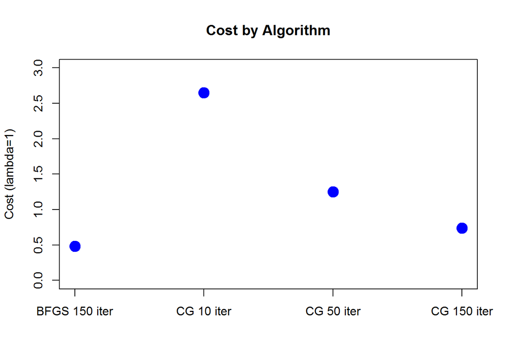

```r
nnCostValues <- c(nnListBFGS150$value, nnListCG010$value, nnListCG050$value, nnListCG150$value)

plot(nnCostValues, xaxt="n", ylab="Cost (lambda=1)", main="Cost by Algorithm",
     pch=19, col="blue", cex=2, xlab="", ylim=c(0, 1 * ceiling(max(nnCostValues)/1) )
     )
axis(1, at=1:4, labels=c("BFGS 150 iter", "CG 10 iter", "CG 50 iter", "CG 150 iter"))
```

Interestingly, though, in this case CG is not converging as quickly to a good solution as had been observed in the BFGS modeling. So, the algorithm may be faster but less accurate in this case.

### *Comparing Accuracies*

Further, we compare the accuracies driven by the varying neural network models. First, a look at BFGS 150 (repeated from above):

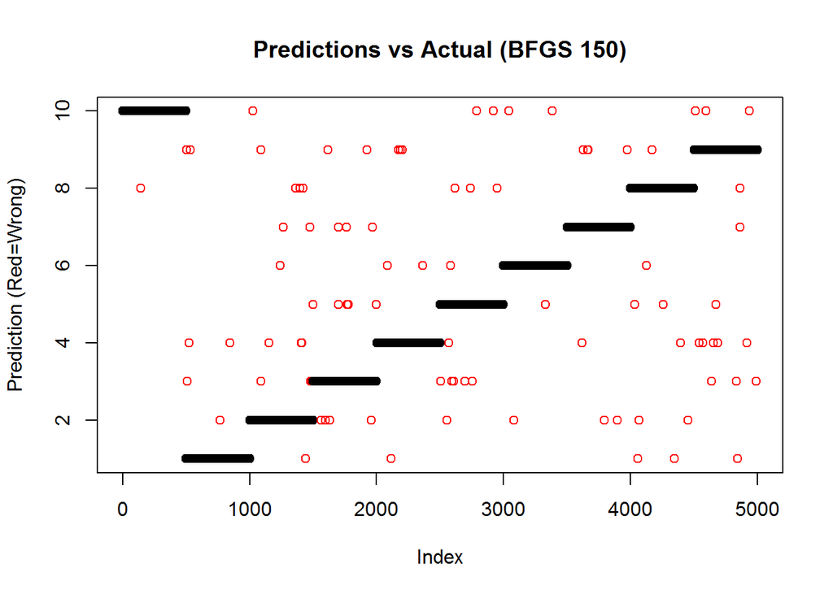

```r
keyCut <- (nInputLayer + 1) * nHiddenNodes
postBPThetaOne <- matrix(data=nnListBFGS150$par[1:keyCut], nrow=nHiddenNodes, byrow=FALSE)
postBPThetaTwo <- matrix(data=nnListBFGS150$par[(keyCut+1):length(nnListBFGS150$par)],
                         nrow=nFinalLabels, byrow=FALSE
                         )

# Assess the optimized accuracies
predYBFGS150 <- forwardPredY(mtxX, postBPThetaOne, postBPThetaTwo)
plot(x=1:length(predYBFGS150), y=predYBFGS150, col = 1 + (mtxY[,1] != predYBFGS150),
     main="Predictions vs Actual (BFGS 150)", ylab="Prediction (Red=Wrong)", xlab="Index"
     )
```

```r
confusionMatrix(predYBFGS150, mtxY[,1])
```

```
## Confusion Matrix and Statistics
##
##           Reference
## Prediction   1   2   3   4   5   6   7   8   9  10
##         1  494   1   0   1   0   0   0   2   1   0
##         2    1 483   4   0   1   1   2   2   0   0
##         3    1   4 487   0   5   0   0   0   3   0
##         4    2   3   0 494   1   0   1   1   5   0
##         5    0   1   4   0 487   1   0   2   1   0
##         6    0   1   0   2   1 496   0   1   0   0
##         7    0   2   3   0   0   0 493   0   1   0
##         8    0   3   0   0   3   0   0 491   1   1
##         9    2   1   2   3   0   0   4   1 485   0
##         10   0   1   0   0   2   2   0   0   3 499
##
## Overall Statistics
##
##                Accuracy : 0.9818
##                  95% CI : (0.9777, 0.9853)
##     No Information Rate : 0.1
##     P-Value [Acc > NIR] : < 2.2e-16
##
##                   Kappa : 0.9798
##  Mcnemar's Test P-Value : NA
##
## Statistics by Class:
##
##                      Class: 1 Class: 2 Class: 3 Class: 4 Class: 5 Class: 6
## Sensitivity            0.9880   0.9660   0.9740   0.9880   0.9740   0.9920
## Specificity            0.9989   0.9976   0.9971   0.9971   0.9980   0.9989
## Pos Pred Value         0.9900   0.9777   0.9740   0.9744   0.9819   0.9900
## Neg Pred Value         0.9987   0.9962   0.9971   0.9987   0.9971   0.9991
## Prevalence             0.1000   0.1000   0.1000   0.1000   0.1000   0.1000
## Detection Rate         0.0988   0.0966   0.0974   0.0988   0.0974   0.0992
## Detection Prevalence   0.0998   0.0988   0.1000   0.1014   0.0992   0.1002
## Balanced Accuracy      0.9934   0.9818   0.9856   0.9926   0.9860   0.9954
##                      Class: 7 Class: 8 Class: 9 Class: 10
## Sensitivity            0.9860   0.9820   0.9700    0.9980
## Specificity            0.9987   0.9982   0.9971    0.9982
## Pos Pred Value         0.9880   0.9840   0.9739    0.9842
## Neg Pred Value         0.9984   0.9980   0.9967    0.9998
## Prevalence             0.1000   0.1000   0.1000    0.1000
## Detection Rate         0.0986   0.0982   0.0970    0.0998
## Detection Prevalence   0.0998   0.0998   0.0996    0.1014
## Balanced Accuracy      0.9923   0.9901   0.9836    0.9981
```

```r
# Print the post-optimization cost
nnCost(vecMatrix=nnListBFGS150$par, nInputLayer, nHiddenNodes, nFinalLabels, X=mtxX, y=mtxY, lambda)
```

```
## [1] 0.4806992
```

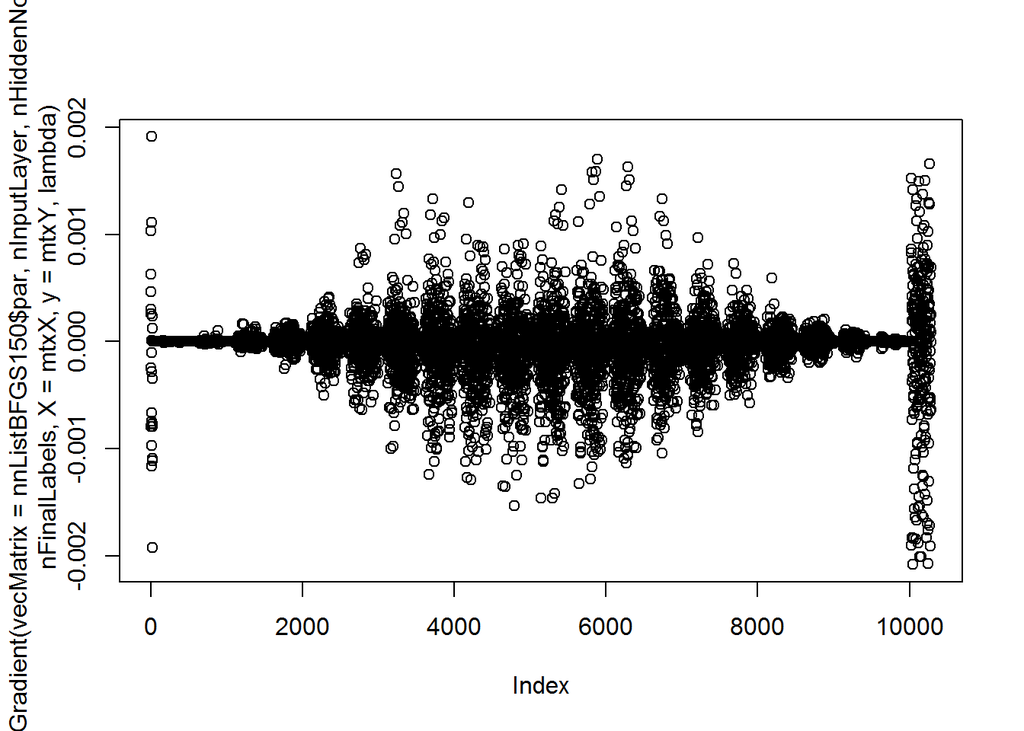

```r
# Plot the post-optimization gradients
plot(nnGradient(vecMatrix=nnListBFGS150$par, nInputLayer, nHiddenNodes, nFinalLabels,
                X=mtxX, y=mtxY, lambda
                )
     )
```

So, the BFGS 150 is driving 98.2% accuracy. Next, we look at the CG 150 outcomes:

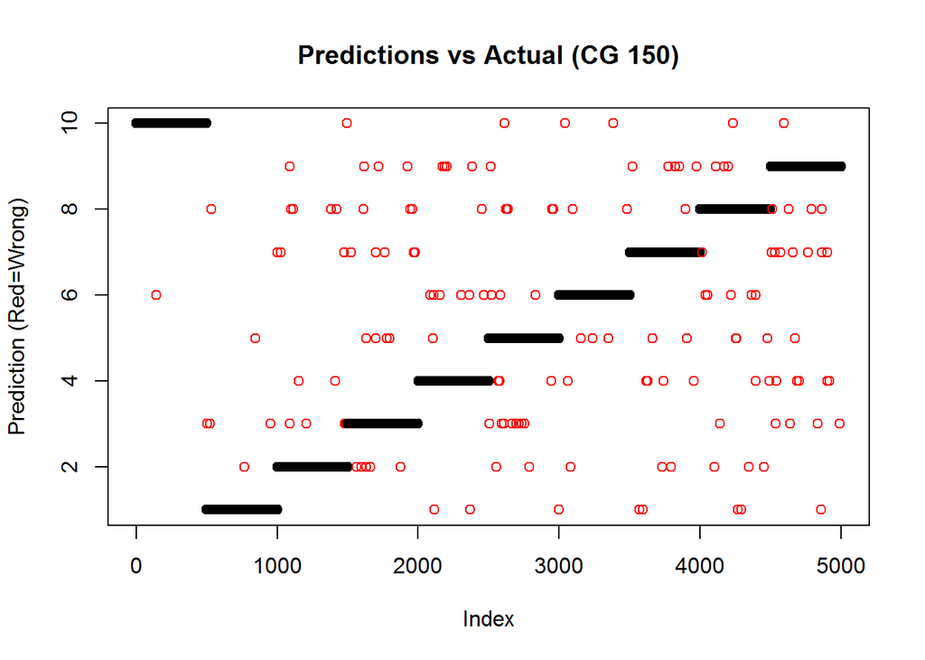

```r
keyCut <- (nInputLayer + 1) * nHiddenNodes
postBPThetaOne <- matrix(data=nnListCG150$par[1:keyCut], nrow=nHiddenNodes, byrow=FALSE)
postBPThetaTwo <- matrix(data=nnListCG150$par[(keyCut+1):length(nnListCG150$par)],
                         nrow=nFinalLabels, byrow=FALSE
                         )

# Assess the optimized accuracies
predYCG150 <- forwardPredY(mtxX, postBPThetaOne, postBPThetaTwo)
plot(x=1:length(predYCG150), y=predYCG150, col = 1 + (mtxY[,1] != predYCG150),
     main="Predictions vs Actual (CG 150)", ylab="Prediction (Red=Wrong)", xlab="Index"
     )
```

```r
confusionMatrix(predYCG150, mtxY[,1])
```

```
## Confusion Matrix and Statistics
##
##           Reference
## Prediction   1   2   3   4   5   6   7   8   9  10
##         1  494   0   0   2   1   0   2   2   1   0
##         2    1 484   5   0   2   1   2   3   0   0
##         3    3   5 480   0   8   0   0   1   5   0
##         4    0   2   0 486   3   1   5   2   5   0
##         5    1   0   4   1 476   3   2   4   1   0
##         6    0   0   0   6   3 491   0   5   0   1
##         7    0   3   5   0   0   0 483   1   7   0
##         8    1   4   3   1   5   2   1 478   4   0
##         9    0   1   3   4   1   0   5   3 476   0
##         10   0   1   0   0   1   2   0   1   1 499
##
## Overall Statistics
##
##                Accuracy : 0.9694
##                  95% CI : (0.9642, 0.974)
##     No Information Rate : 0.1
##     P-Value [Acc > NIR] : < 2.2e-16
##
##                   Kappa : 0.966
##  Mcnemar's Test P-Value : NA
##
## Statistics by Class:
##
##                      Class: 1 Class: 2 Class: 3 Class: 4 Class: 5 Class: 6
## Sensitivity            0.9880   0.9680   0.9600   0.9720   0.9520   0.9820
## Specificity            0.9982   0.9969   0.9951   0.9960   0.9964   0.9967
## Pos Pred Value         0.9841   0.9719   0.9562   0.9643   0.9675   0.9704
## Neg Pred Value         0.9987   0.9964   0.9956   0.9969   0.9947   0.9980
## Prevalence             0.1000   0.1000   0.1000   0.1000   0.1000   0.1000
## Detection Rate         0.0988   0.0968   0.0960   0.0972   0.0952   0.0982
## Detection Prevalence   0.1004   0.0996   0.1004   0.1008   0.0984   0.1012
## Balanced Accuracy      0.9931   0.9824   0.9776   0.9840   0.9742   0.9893
##                      Class: 7 Class: 8 Class: 9 Class: 10
## Sensitivity            0.9660   0.9560   0.9520    0.9980
## Specificity            0.9964   0.9953   0.9962    0.9987
## Pos Pred Value         0.9679   0.9579   0.9655    0.9881
## Neg Pred Value         0.9962   0.9951   0.9947    0.9998
## Prevalence             0.1000   0.1000   0.1000    0.1000
## Detection Rate         0.0966   0.0956   0.0952    0.0998
## Detection Prevalence   0.0998   0.0998   0.0986    0.1010
## Balanced Accuracy      0.9812   0.9757   0.9741    0.9983
```

```r
# Print the post-optimization cost
nnCost(vecMatrix=nnListCG150$par, nInputLayer, nHiddenNodes, nFinalLabels, X=mtxX, y=mtxY, lambda)
```

```
## [1] 0.7400523
```

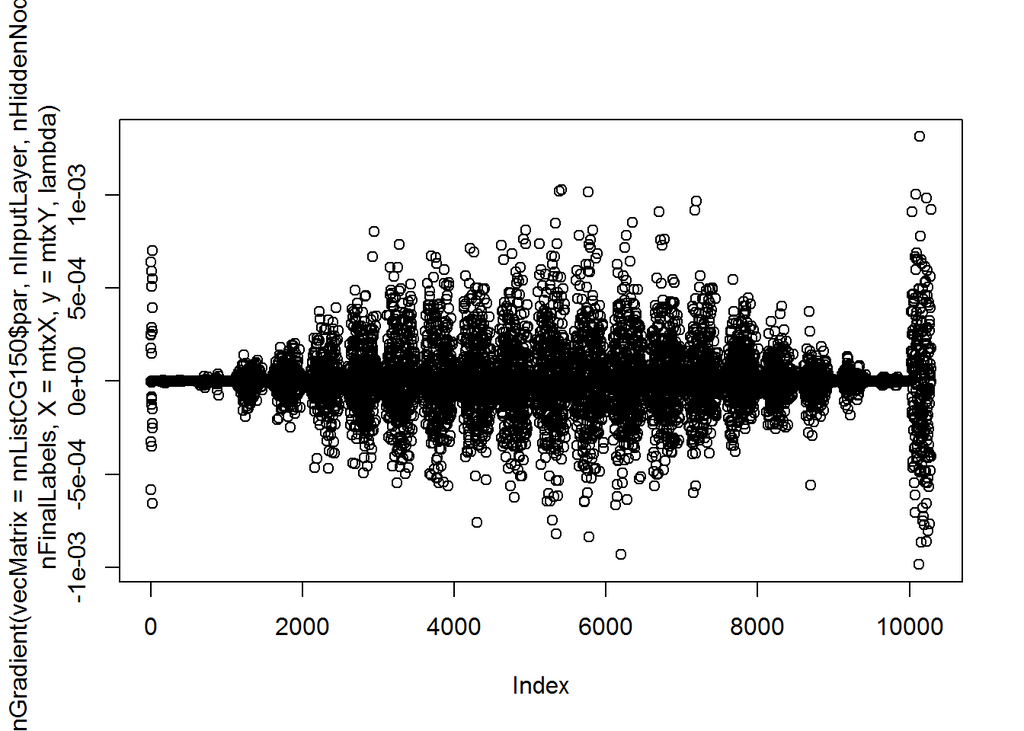

```r
# Plot the post-optimization gradients
plot(nnGradient(vecMatrix=nnListCG150$par, nInputLayer, nHiddenNodes, nFinalLabels,
                X=mtxX, y=mtxY, lambda
                )
     )
```

While the CG 150 is driving to 96.9% accuracy (1.3% higher classification error than BFGS 150). And, we check that the starting cost is the same as the base case:

```r
vecPass=c(as.vector(bpThetaOne), as.vector(bpThetaTwo))  # Roll together bpThetaOne and bpThetaTwo
nnCost(vecMatrix=vecPass, nInputLayer, nHiddenNodes, nFinalLabels, X=mtxX, y=mtxY, lambda=1)
```

```
## [1] 6.599944
```

Lastly, we look at the CG 50 outcomes:

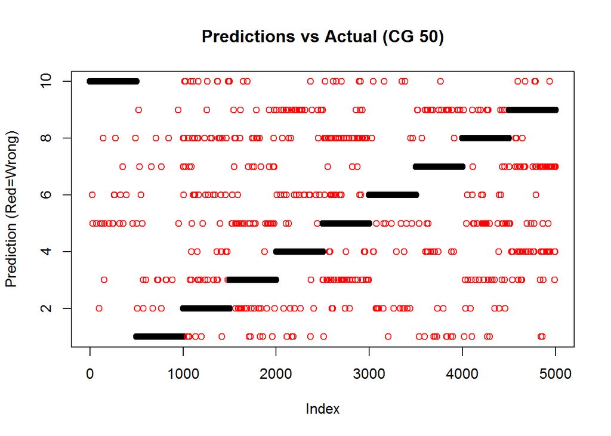

```r
keyCut <- (nInputLayer + 1) * nHiddenNodes
postBPThetaOne <- matrix(data=nnListCG050$par[1:keyCut], nrow=nHiddenNodes, byrow=FALSE)
postBPThetaTwo <- matrix(data=nnListCG050$par[(keyCut+1):length(nnListCG050$par)],
                         nrow=nFinalLabels, byrow=FALSE
                         )

# Assess the optimized accuracies
predYCG050 <- forwardPredY(mtxX, postBPThetaOne, postBPThetaTwo)
plot(x=1:length(predYCG050), y=predYCG050, col = 1 + (mtxY[,1] != predYCG050),
     main="Predictions vs Actual (CG 50)", ylab="Prediction (Red=Wrong)", xlab="Index"
     )
```

```r
confusionMatrix(predYCG050, mtxY[,1])
```

```
## Confusion Matrix and Statistics
##
##           Reference
## Prediction   1   2   3   4   5   6   7   8   9  10
##         1  478   6   5   4   1   1   9   4   2   0
##         2    4 424  18   5   5  13   2   5   0   1
##         3    7  11 420   1  28   0   0  12   8   1
##         4    0   9   1 443   6   4  10   1  28   0
##         5    3   3  28   3 403   7   3  25   7  13
##         6    1  12   2  14  13 468   0   7   1   5
##         7    3   5   8   0   3   0 455   3  36   1
##         8    2  17  11   4  31   3   2 432   3   3
##         9    2   1   5  25   3   0  18  11 409   0
##         10   0  12   2   1   7   4   1   0   6 476
##
## Overall Statistics
##
##                Accuracy : 0.8816
##                  95% CI : (0.8723, 0.8904)
##     No Information Rate : 0.1
##     P-Value [Acc > NIR] : < 2.2e-16
##
##                   Kappa : 0.8684
##  Mcnemar's Test P-Value : NA
##
## Statistics by Class:
##
##                      Class: 1 Class: 2 Class: 3 Class: 4 Class: 5 Class: 6
## Sensitivity            0.9560   0.8480   0.8400   0.8860   0.8060   0.9360
## Specificity            0.9929   0.9882   0.9849   0.9869   0.9796   0.9878
## Pos Pred Value         0.9373   0.8889   0.8607   0.8825   0.8141   0.8948
## Neg Pred Value         0.9951   0.9832   0.9823   0.9873   0.9785   0.9929
## Prevalence             0.1000   0.1000   0.1000   0.1000   0.1000   0.1000
## Detection Rate         0.0956   0.0848   0.0840   0.0886   0.0806   0.0936
## Detection Prevalence   0.1020   0.0954   0.0976   0.1004   0.0990   0.1046
## Balanced Accuracy      0.9744   0.9181   0.9124   0.9364   0.8928   0.9619
##                      Class: 7 Class: 8 Class: 9 Class: 10
## Sensitivity            0.9100   0.8640   0.8180    0.9520
## Specificity            0.9869   0.9831   0.9856    0.9927
## Pos Pred Value         0.8852   0.8504   0.8629    0.9352
## Neg Pred Value         0.9900   0.9849   0.9799    0.9947
## Prevalence             0.1000   0.1000   0.1000    0.1000
## Detection Rate         0.0910   0.0864   0.0818    0.0952
## Detection Prevalence   0.1028   0.1016   0.0948    0.1018
## Balanced Accuracy      0.9484   0.9236   0.9018    0.9723
```

```r
# Print the post-optimization cost
nnCost(vecMatrix=nnListCG050$par, nInputLayer, nHiddenNodes, nFinalLabels, X=mtxX, y=mtxY, lambda)
```

```
## [1] 1.270399
```

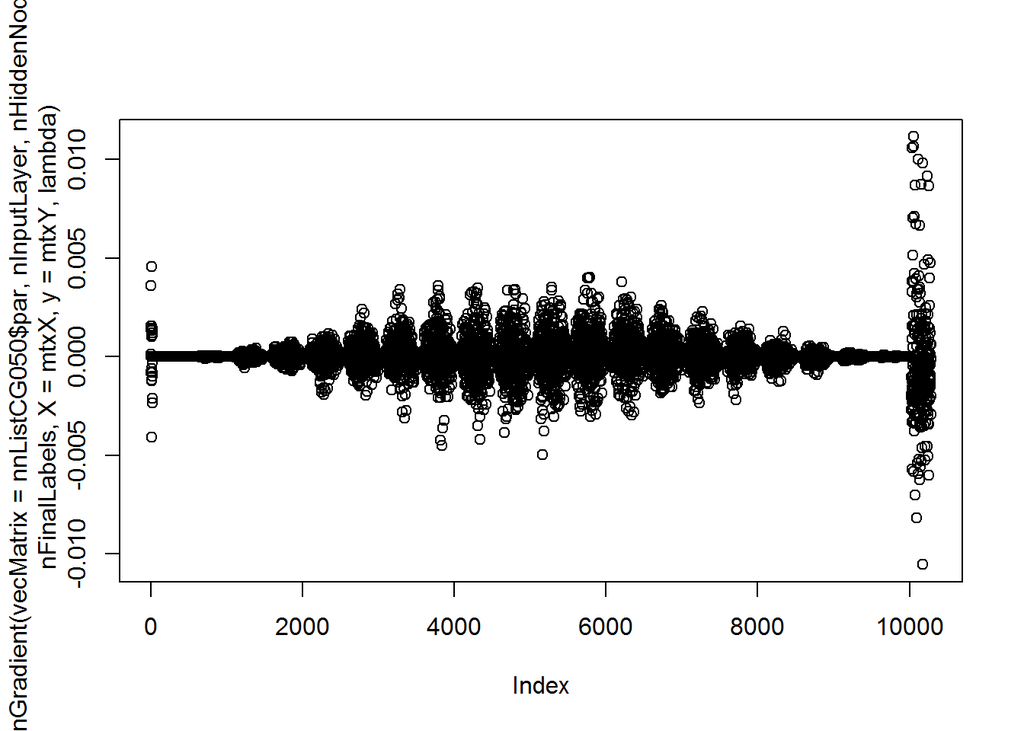

```r
# Plot the post-optimization gradients
plot(nnGradient(vecMatrix=nnListCG050$par, nInputLayer, nHiddenNodes, nFinalLabels,
                X=mtxX, y=mtxY, lambda
                )
     )
```

And, accuracy here is only 88%, suggestive that 50 iterations of CG in R is driving to a less optimal outcome than 50 iterations of CG in Octave (which hits ~95%). So, perhaps there is still further tuning to explore?